# Pendugaan Parameter, Diagnostik Model, dan Peramalan

G1401211043_Yogi Nur Hamid

2023-09-30

## Packages

```r
library(ggplot2)
library(tsibble)
library(tseries)
library(MASS)
library(forecast)
library(TSA)
library(TTR)
library(aTSA)
library(graphics)
```

# Data Asli

Digunakan data jumlah penumpang KRL sebanyak 150 periode awal

```r
data <- rio::import("https://raw.githubusercontent.com/yoginurhamid/MPDW/main/Data/Data%20Prak%201.csv")
data <- data[1:150,2]
n <- NROW(data)
data.ts <- ts(data)
```

# Eksplorasi Data

## Plot Data Penuh

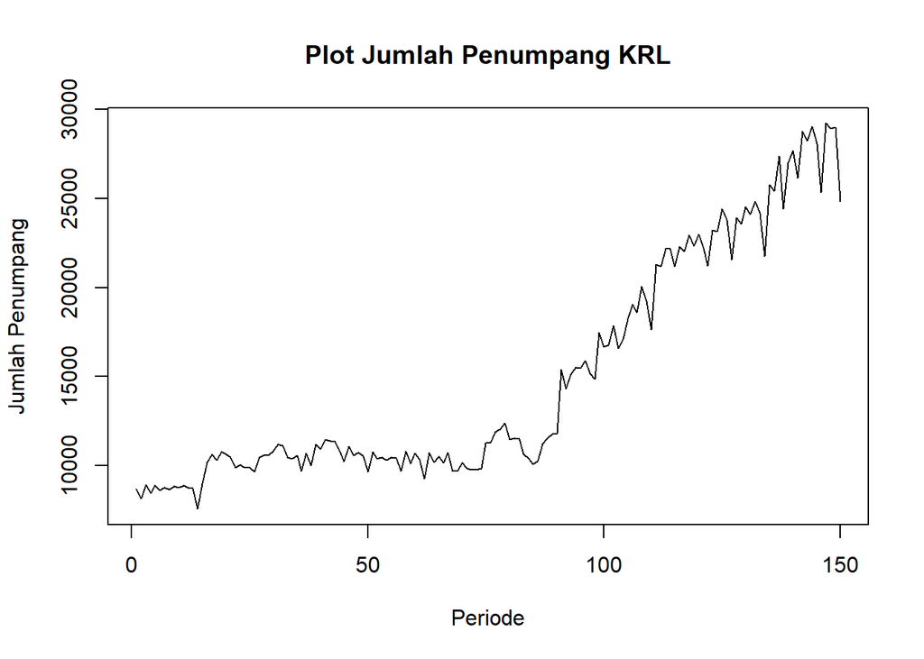

```r
plot.ts(data.ts, lty=1, xlab="Periode", ylab="Jumlah Penumpang", main="Plot Jumlah Penumpang KRL")
```

Berdasarkan plot data deret waktu, terlihat bahwa data cenderung memiliki trend yang naik. Berdasarkan pola data, pembagian data latih dan data uji ditetapkan dengan proporsi 86%:14%.

## Plot Data Latih

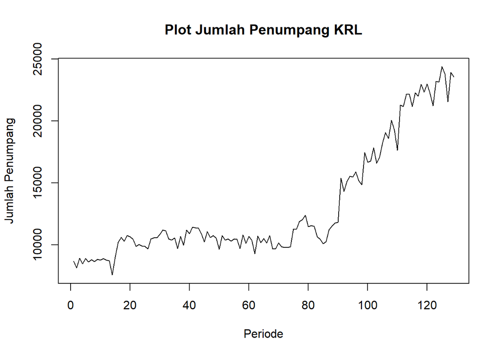

```r
data.train<-data[1:(0.86*n)]
train.ts<-ts(data.train)
plot.ts(train.ts, lty=1, xlab="Periode", ylab="Jumlah Penumpang", main="Plot Jumlah Penumpang KRL")
```

Berdasarkan plot data deret waktu pada data latih, terlihat bahwa data cenderung memiliki trend yang naik dan cenderung tidak bergerak pada nilai tengah tertentu. Hal ini mengindikasikan bahwa data tidak stasioner dalam rataan.

## Plot Data Uji

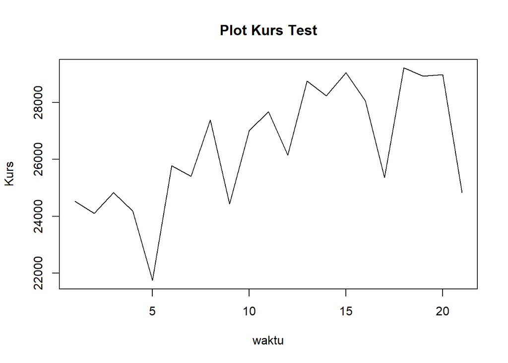

```r
data.test<-data[(0.86*n+1):n]
test.ts<-ts(data.test)
plot.ts(test.ts, lty=1, xlab="waktu", ylab="Kurs", main="Plot Kurs Test")
```

# Uji Stasioneritas Data

## Plot ACF

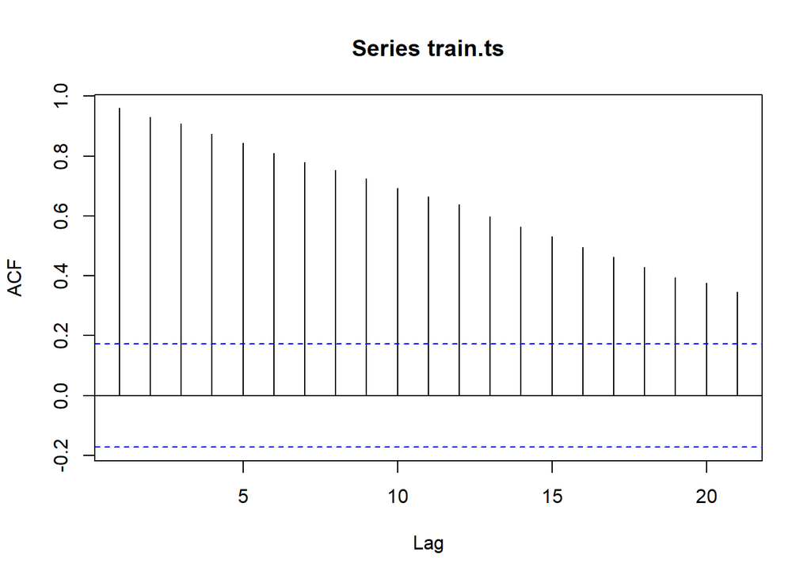

```r
acf(train.ts)
```

Berdasarkan plot ACF, terlihat bahwa plot ACF data menurun secara perlahan (*tails of slowly*). Hal ini juga menjadi indikasi bahwa data tidak stasioner dalam rataan.

## Uji ADF

```r
tseries::adf.test(train.ts)
```

```
##
##  Augmented Dickey-Fuller Test
##
## data:  train.ts
## Dickey-Fuller = -0.70177, Lag order = 5, p-value = 0.968
## alternative hypothesis: stationary
```

$H_0$ : Data tidak stasioner dalam rataan

$H_1$ : Data stasioner dalam rataan

Berdasarkan uji ADF tersebut, didapat *p-value* sebesar 0.9681 yang lebih besar dari taraf nyata 5% sehingga tak tolak $H_0$ dan menandakan bahwa data tidak stasioner dalam rataan. Hal ini sesuai dengan hasil eksplorasi menggunakan plot time series dan plot ACF, sehingga ketidakstasioneran model kedepannya harus ditangani.

## Plot Box-Cox

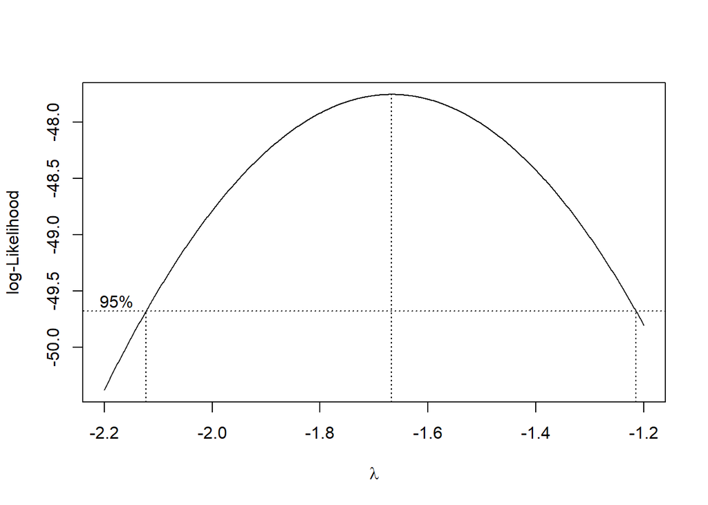

```r
index <- seq(1:(0.86*n))
bc = boxcox(train.ts~index, lambda = seq(-2.2,-1.2,by=0.001))
```

```r
#Nilai Rounded Lambda
lambda <- bc$x[which.max(bc$y)]
lambda
```

```
## [1] -1.668
```

```r
#SK
bc$x[bc$y > max(bc$y) - 1/2 * qchisq(.95,1)]
```

```
##   [1] -2.122 -2.121 -2.120 -2.119 -2.118 -2.117 -2.116 -2.115 -2.114 -2.113
##  [11] -2.112 -2.111 -2.110 -2.109 -2.108 -2.107 -2.106 -2.105 -2.104 -2.103
##  [21] -2.102 -2.101 -2.100 -2.099 -2.098 -2.097 -2.096 -2.095 -2.094 -2.093
##  [31] -2.092 -2.091 -2.090 -2.089 -2.088 -2.087 -2.086 -2.085 -2.084 -2.083
##  [41] -2.082 -2.081 -2.080 -2.079 -2.078 -2.077 -2.076 -2.075 -2.074 -2.073
##  [51] -2.072 -2.071 -2.070 -2.069 -2.068 -2.067 -2.066 -2.065 -2.064 -2.063
##  [61] -2.062 -2.061 -2.060 -2.059 -2.058 -2.057 -2.056 -2.055 -2.054 -2.053
##  [71] -2.052 -2.051 -2.050 -2.049 -2.048 -2.047 -2.046 -2.045 -2.044 -2.043
##  [81] -2.042 -2.041 -2.040 -2.039 -2.038 -2.037 -2.036 -2.035 -2.034 -2.033
##  [91] -2.032 -2.031 -2.030 -2.029 -2.028 -2.027 -2.026 -2.025 -2.024 -2.023
## [101] -2.022 -2.021 -2.020 -2.019 -2.018 -2.017 -2.016 -2.015 -2.014 -2.013
## [111] -2.012 -2.011 -2.010 -2.009 -2.008 -2.007 -2.006 -2.005 -2.004 -2.003
## [121] -2.002 -2.001 -2.000 -1.999 -1.998 -1.997 -1.996 -1.995 -1.994 -1.993
## [131] -1.992 -1.991 -1.990 -1.989 -1.988 -1.987 -1.986 -1.985 -1.984 -1.983
## [141] -1.982 -1.981 -1.980 -1.979 -1.978 -1.977 -1.976 -1.975 -1.974 -1.973
```

[output cut: 76 more lines]

Plot Boxcox menunjukkan nilai *rounded value* ($\lambda$) optimum sebesar **-1.668** dan pada selang kepercayaan 95% nilai memiliki batas bawah **-2.122** dan batas atas **-1.215**. Selang tersebut tidak memuat nilai satu sehingga dapat dikatakan bahwa data jumlah penumpang KRL tidak stasioner dalam ragam.

# Penanganan Ketidakstasioneran Data

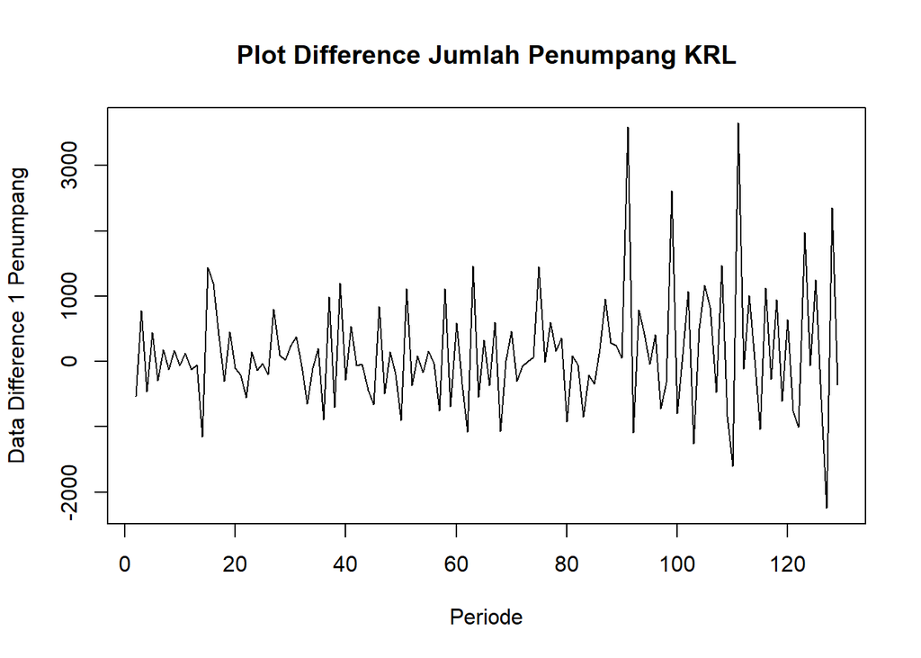

```r
train.diff <- diff(train.ts,differences = 1)
plot.ts(train.diff, lty=1, xlab="Periode", ylab="Data Difference 1 Penumpang", main="Plot Difference Jumlah Penumpang KRL")
```

Berdasarkan plot data deret waktu, terlihat bahwa data sudah stasioner dalam rataan ditandai dengan data bergerak pada nilai tengah tertentu (tidak terdapat trend ataupun musiman pada data).

## Plot ACF

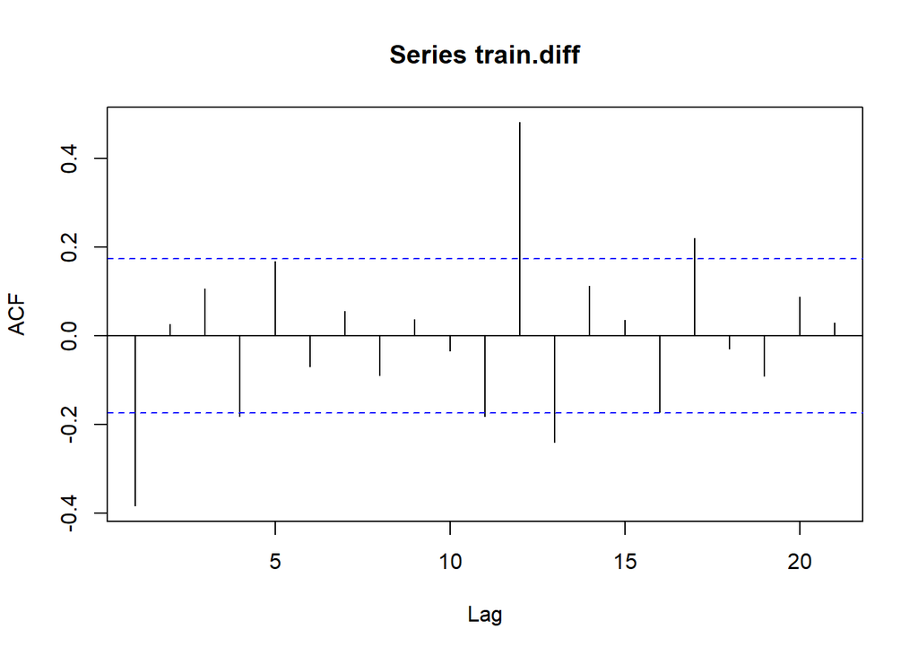

```r
acf(train.diff)
```

Berdasarkan plot tersebut, terlihat bahwa plot ACF *cuts off* pada lag ke 1. Hal ini menandakan data sudah stasioner dalam rataan dan ketidakstasioneran data telah berhasil tertangani.

## Uji ADF

```r
tseries::adf.test(train.diff)
```

```
##
##  Augmented Dickey-Fuller Test
##
## data:  train.diff
## Dickey-Fuller = -5.0681, Lag order = 5, p-value = 0.01
## alternative hypothesis: stationary
```

$H_0$ : Data tidak stasioner dalam rataan

$H_1$ : Data stasioner dalam rataan

Berdasarkan uji ADF tersebut, didapat *p-value* sebesar 0.01 yang lebih kecil dari taraf nyata 5% sehingga tolak $H_0$ atau data stasioner dalam rataan. Hal ini sesuai dengan hasil eksplorasi menggunakan plot time series dan plot ACF, sehingga dalam hal ini ketidakstasioneran data sudah berhasil ditangani dan dapat dilanjutkan ke pemodelan

# Identifikasi Model

## Plot ACF

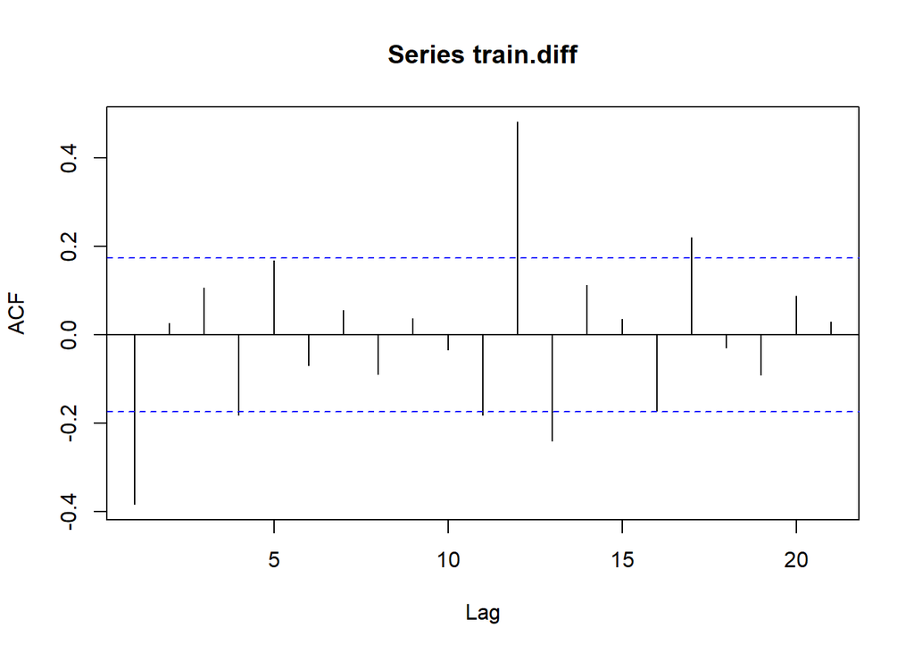

```r
acf(train.diff)
```

Berdasarkan plot tersebut, terlihat bahwa plot ACF cenderung *cuts off* pada lag ke 1, sehingga jika plot PACF dianggap *tails of*, maka model tentatifnya adalah ARIMA(0,1,1).

## Plot PACF

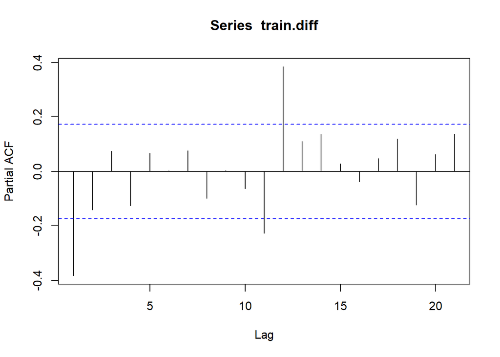

```r
pacf(train.diff)
```

Berdasarkan plot tersebut, terlihat bahwa plot PACF cenderung *cuts off*

## Plot EACF

```r
eacf(train.diff)
```

```
## AR/MA
##   0 1 2 3 4 5 6 7 8 9 10 11 12 13
## 0 x o o x o o o o o o o  x  x  o
## 1 x o o o o o o o o o o  x  o  o
## 2 x o o o o o o o o o o  x  o  o
## 3 x x o o o o o o o o o  x  o  o
## 4 x x x o o o o o o o o  x  x  x
## 5 o o x o o o o o o o o  x  o  x
## 6 o x x o o o o o o o o  x  o  x
## 7 x x x o o o o o o o o  x  o  o
```

Identifikasi model menggunakan plot EACF dilakukan dengan melihat ujung segitiga pada pola segitiga nol. Dalam hal ini model tentatif yang terbentuk adalah ARIMA(0,1,1), ARIMA(0,1,2), ARIMA(1,1,1), ARIMA(1,1,2), ARIMA(1,1,3), ARIMA(2,1,1), ARIMA(2,1,2), ARIMA(2,1,3), ARIMA(3,1,2), dan ARIMA(3,1,3).

# Pendugaan Parameter Model Tentatif

## ARIMA(0,1,1)

```r
model1.da=Arima(train.diff, order=c(0,1,1),method="ML")
summary(model1.da) #AIC=2092.29
```

```
## Series: train.diff
## ARIMA(0,1,1)
##
## Coefficients:
##           ma1
##       -1.0000
## s.e.   0.0746
##
## sigma^2 = 786260:  log likelihood = -1044.14
## AIC=2092.29   AICc=2092.39   BIC=2097.98
##
## Training set error measures:
##                    ME     RMSE      MAE      MPE     MAPE      MASE       ACF1
## Training set 65.69397 879.7582 620.2589 97.90902 116.9337 0.5709338 -0.3872001
```

```r
lmtest::coeftest(model1.da) #seluruh parameter signifikan
```

```
##
## z test of coefficients:
##
##      Estimate Std. Error z value  Pr(>|z|)
## ma1 -0.999999   0.074613 -13.402 < 2.2e-16 ***
## ---
## Signif. codes:  0 '***' 0.001 '**' 0.01 '*' 0.05 '.' 0.1 ' ' 1
```

## ARIMA(0,1,2)

```r
model2.da=Arima(train.diff, order=c(0,1,2),method="ML")
summary(model2.da) #AIC=2071.86
```

```
## Series: train.diff
## ARIMA(0,1,2)
##
## Coefficients:
##           ma1     ma2
##       -1.4012  0.4263
## s.e.   0.0801  0.0797
##
## sigma^2 = 669995:  log likelihood = -1032.93
## AIC=2071.86   AICc=2072.06   BIC=2080.39
##
## Training set error measures:
##                    ME     RMSE      MAE      MPE     MAPE      MASE        ACF1
## Training set 51.96941 808.8829 572.0293 25.43803 191.4197 0.5265396 -0.02781817
```

```r
lmtest::coeftest(model2.da) #seluruh parameter signifikan
```

```
##
## z test of coefficients:
##
##      Estimate Std. Error  z value  Pr(>|z|)
## ma1 -1.401187   0.080120 -17.4885 < 2.2e-16 ***
## ma2  0.426257   0.079711   5.3476 8.915e-08 ***
## ---
## Signif. codes:  0 '***' 0.001 '**' 0.01 '*' 0.05 '.' 0.1 ' ' 1
```

## ARIMA(1,1,1)

```r
model3.da=Arima(train.diff, order=c(1,1,1),method="ML")
summary(model3.da) #AIC=2074.15
```

```
## Series: train.diff
## ARIMA(1,1,1)
##
## Coefficients:
##           ar1      ma1
##       -0.3881  -0.9737
## s.e.   0.0823   0.0254
##
## sigma^2 = 682174:  log likelihood = -1034.08
## AIC=2074.15   AICc=2074.35   BIC=2082.69
##
## Training set error measures:
##                    ME     RMSE      MAE      MPE     MAPE     MASE        ACF1
## Training set 58.88689 816.2021 557.5122 6.438959 180.5831 0.513177 -0.06852829
```

```r
lmtest::coeftest(model3.da) #seluruh parameter signifikan
```

```
##
## z test of coefficients:
##
##      Estimate Std. Error  z value  Pr(>|z|)
## ar1 -0.388074   0.082331  -4.7136 2.434e-06 ***
## ma1 -0.973719   0.025359 -38.3976 < 2.2e-16 ***
## ---
## Signif. codes:  0 '***' 0.001 '**' 0.01 '*' 0.05 '.' 0.1 ' ' 1
```

## ARIMA(1,1,2)

```r
model4.da=Arima(train.diff, order=c(1,1,2),method="ML")
summary(model4.da) #AIC=2073.64
```

```
## Series: train.diff
## ARIMA(1,1,2)
##
## Coefficients:
##           ar1      ma1     ma2
##       -0.1050  -1.3109  0.3372
## s.e.   0.2181   0.2093  0.2070
##
## sigma^2 = 674191:  log likelihood = -1032.82
## AIC=2073.64   AICc=2073.97   BIC=2085.02
##
## Training set error measures:
##                    ME     RMSE      MAE      MPE     MAPE      MASE        ACF1
## Training set 53.40024 808.1598 565.8031 15.13793 193.7807 0.5208085 -0.01316566
```

```r
lmtest::coeftest(model4.da) #terdapat parameter tidak signifikan
```

```
##
## z test of coefficients:
##
##     Estimate Std. Error z value  Pr(>|z|)
## ar1 -0.10498    0.21810 -0.4813    0.6303
## ma1 -1.31089    0.20927 -6.2640 3.752e-10 ***
## ma2  0.33716    0.20699  1.6289    0.1033
## ---
## Signif. codes:  0 '***' 0.001 '**' 0.01 '*' 0.05 '.' 0.1 ' ' 1
```

## ARIMA(1,1,3)

```r
model5.da=Arima(train.diff, order=c(1,1,3),method="ML")
summary(model5.da) #AIC=2075.86
```

[output not shown]

```
##           ar1      ma1      ma2     ma3
##       -0.4908  -0.9083  -0.2709  0.2168
## s.e.      NaN      NaN      NaN     NaN
##
## sigma^2 = 680850:  log likelihood = -1032.93
## AIC=2075.86   AICc=2076.35   BIC=2090.08
##
## Training set error measures:
##                   ME     RMSE      MAE      MPE     MAPE      MASE        ACF1
## Training set 51.8013 808.8596 573.1164 26.72172 191.3739 0.5275403 -0.02918647
```

```r
lmtest::coeftest(model5.da) #Tidak ada parameter yang signifikan
```

```
##
## z test of coefficients:
##
##     Estimate Std. Error z value Pr(>|z|)
## ar1 -0.49081        NaN     NaN      NaN
## ma1 -0.90834        NaN     NaN      NaN
## ma2 -0.27088        NaN     NaN      NaN
## ma3  0.21682        NaN     NaN      NaN
```

## ARIMA(2,1,1)

```r
model6.da=Arima(train.diff, order=c(2,1,1),method="ML")
summary(model6.da) #AIC=2073.17
```

```
## Series: train.diff
## ARIMA(2,1,1)
##
## Coefficients:
##           ar1      ar2      ma1
##       -0.4544  -0.1595  -0.9637
## s.e.   0.0897   0.0916   0.0287
##
## sigma^2 = 671627:  log likelihood = -1032.59
## AIC=2073.17   AICc=2073.5   BIC=2084.55
##
## Training set error measures:
##                    ME     RMSE      MAE     MPE     MAPE     MASE         ACF1
## Training set 54.55785 806.6218 565.6515 2.26716 200.2292 0.520669 -0.002873591
```

```r
lmtest::coeftest(model6.da) #terdapat parameter yang tidak signifikan
```

```
##
## z test of coefficients:
##
##      Estimate Std. Error  z value  Pr(>|z|)
## ar1 -0.454412   0.089721  -5.0647  4.09e-07 ***
## ar2 -0.159546   0.091605  -1.7417   0.08156 .
## ma1 -0.963657   0.028666 -33.6171 < 2.2e-16 ***
## ---
## Signif. codes:  0 '***' 0.001 '**' 0.01 '*' 0.05 '.' 0.1 ' ' 1
```

## ARIMA(2,1,2)

```r
model7.da=Arima(train.diff, order=c(2,1,2),method="ML")
summary(model7.da) #AIC=2072.25
```

```
## Series: train.diff
## ARIMA(2,1,2)
##
## Coefficients:
##           ar1      ar2      ma1      ma2
##       -1.0962  -0.4169  -0.2937  -0.6523
## s.e.   0.1526   0.0867   0.1486   0.1453
##
## sigma^2 = 661287:  log likelihood = -1031.12
## AIC=2072.25   AICc=2072.74   BIC=2086.47
##
## Training set error measures:
##                    ME     RMSE      MAE    MPE     MAPE      MASE         ACF1
## Training set 56.70527 797.1547 570.9642 20.048 192.7501 0.5255592 -0.007770428
```

```r
lmtest::coeftest(model7.da) #seluruh parameter signifikan
```

```
##
## z test of coefficients:
##
##      Estimate Std. Error z value  Pr(>|z|)
## ar1 -1.096214   0.152648 -7.1813 6.905e-13 ***
## ar2 -0.416866   0.086715 -4.8073 1.530e-06 ***
## ma1 -0.293718   0.148631 -1.9761   0.04814 *
## ma2 -0.652333   0.145316 -4.4891 7.153e-06 ***
## ---
## Signif. codes:  0 '***' 0.001 '**' 0.01 '*' 0.05 '.' 0.1 ' ' 1
```

## ARIMA(2,1,3)

```r
model8.da=Arima(train.diff, order=c(2,1,3),method="ML")
summary(model8.da) #AIC=2074.19
```

```
## Series: train.diff
## ARIMA(2,1,3)
##
## Coefficients:
##           ar1      ar2      ma1      ma2      ma3
##       -1.1424  -0.4674  -0.2365  -0.6511  -0.0580
## s.e.   0.2407   0.2197   0.2807   0.1434   0.2376
##
## sigma^2 = 666338:  log likelihood = -1031.09
## AIC=2074.19   AICc=2074.89   BIC=2091.25
##
## Training set error measures:
##                    ME    RMSE      MAE      MPE     MAPE      MASE       ACF1
## Training set 57.53086 796.934 572.1774 18.77249 192.7278 0.5266759 -0.0160143
```

```r
lmtest::coeftest(model8.da) #terdapat parameter yang tidak signifikan
```

```
##
## z test of coefficients:
##
##      Estimate Std. Error z value  Pr(>|z|)
## ar1 -1.142421   0.240659 -4.7470 2.064e-06 ***
## ar2 -0.467410   0.219651 -2.1280   0.03334 *
## ma1 -0.236460   0.280748 -0.8423   0.39965
## ma2 -0.651138   0.143406 -4.5405 5.611e-06 ***
## ma3 -0.058043   0.237579 -0.2443   0.80699
## ---
## Signif. codes:  0 '***' 0.001 '**' 0.01 '*' 0.05 '.' 0.1 ' ' 1
```

## ARIMA(3,1,2)

```r
model9.da=Arima(train.diff, order=c(3,1,2),method="ML")
summary(model9.da) #AIC=2074.22
```

```
## Series: train.diff
## ARIMA(3,1,2)
##
## Coefficients:
##           ar1      ar2     ar3      ma1      ma2
##       -1.0762  -0.3948  0.0176  -0.3086  -0.6394
## s.e.   0.1981   0.1590  0.1062   0.1788   0.1697
##
## sigma^2 = 666541:  log likelihood = -1031.11
## AIC=2074.22   AICc=2074.92   BIC=2091.28
##
## Training set error measures:
##                    ME    RMSE      MAE      MPE     MAPE      MASE        ACF1
## Training set 57.08936 797.055 571.5423 19.04787 192.9808 0.5260913 -0.01152157
```

```r
lmtest::coeftest(model9.da) #terdapat parameter yang tidak signifikan
```

```
##
## z test of coefficients:
##
##      Estimate Std. Error z value  Pr(>|z|)
## ar1 -1.076179   0.198093 -5.4327 5.551e-08 ***
## ar2 -0.394787   0.159043 -2.4823 0.0130552 *
## ar3  0.017595   0.106208  0.1657 0.8684180
## ma1 -0.308648   0.178765 -1.7266 0.0842464 .
## ma2 -0.639441   0.169708 -3.7679 0.0001646 ***
## ---
## Signif. codes:  0 '***' 0.001 '**' 0.01 '*' 0.05 '.' 0.1 ' ' 1
```

## ARIMA(3,1,3)

```r
model10.da=Arima(train.diff, order=c(3,1,3),method="ML")
summary(model10.da) #AIC=2073.26
```

```
## Series: train.diff
## ARIMA(3,1,3)
##
## Coefficients:
##           ar1     ar2     ar3      ma1      ma2     ma3
##       -0.2313  0.5261  0.2911  -1.2235  -0.4255  0.6862
## s.e.   0.1617  0.1226  0.0968   0.1490   0.2673  0.1370
##
## sigma^2 = 649908:  log likelihood = -1029.63
## AIC=2073.26   AICc=2074.2   BIC=2093.17
##
## Training set error measures:
##                    ME     RMSE      MAE      MPE     MAPE      MASE       ACF1
## Training set -9.05215 783.8152 564.1549 13.49272 192.3619 0.5192914 0.02156943
```

```r
lmtest::coeftest(model10.da) #terdapat parameter yang tidak signifikan
```

```
##
## z test of coefficients:
##
##      Estimate Std. Error z value  Pr(>|z|)
## ar1 -0.231281   0.161722 -1.4301  0.152685
## ar2  0.526104   0.122600  4.2912 1.777e-05 ***
## ar3  0.291114   0.096763  3.0085  0.002625 **
## ma1 -1.223545   0.148969 -8.2134 < 2.2e-16 ***
## ma2 -0.425491   0.267304 -1.5918  0.111433
## ma3  0.686186   0.136995  5.0089 5.475e-07 ***
## ---
## Signif. codes:  0 '***' 0.001 '**' 0.01 '*' 0.05 '.' 0.1 ' ' 1
```

Berdasarkan pendugaan parameter di atas, nilai AIC terkecil dimiliki oleh model ARIMA(0,1,2) dan parameter model ARIMA(0,1,2) juga seluruhnya signifikan sehingga model yang dipilih adalah model ARIMA(0,1,2).

# Analisis Sisaan

Model terbaik hasil identifikasi kemudian dicek asumsi sisaannya. Sisaan model ARIMA harus memenuhi asumsi normalitas, kebebasan sisaan, dan kehomogenan ragam. Diagnostik model dilakukan secara eksplorasi dan uji formal.

## Eksplorasi Sisaan

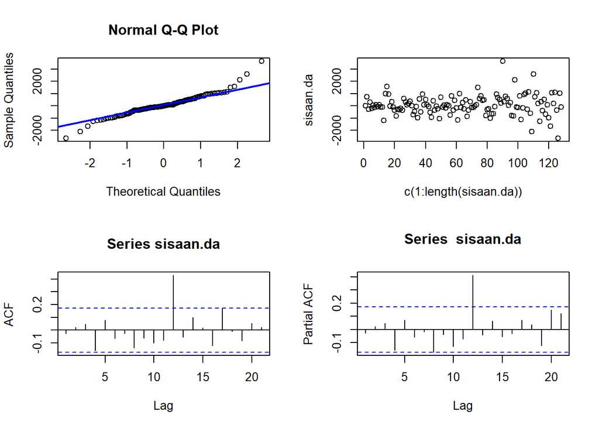

```r
#Eksplorasi
sisaan.da <- model2.da$residuals
par(mfrow=c(2,2))
qqnorm(sisaan.da)
qqline(sisaan.da, col = "blue", lwd = 2)
plot(c(1:length(sisaan.da)),sisaan.da)
acf(sisaan.da)
pacf(sisaan.da)
```

```r
par(mfrow = c(1,1))
```

## Uji Formal

###1) Sisaan Menyebar Normal

```r
ks.test(sisaan.da,"pnorm")
```

```
##
##  Asymptotic one-sample Kolmogorov-Smirnov test
##
## data:  sisaan.da
## D = 0.51562, p-value < 2.2e-16
## alternative hypothesis: two-sided
```

Selain dengan eksplorasi, asumsi tersebut dapat diuji menggunakan uji formal. Pada tahapan ini uji formal yang digunakan untuk normalitas adalah uji Kolmogorov-Smirnov (KS). Hipotesis pada uji KS adalah sebagai berikut.

$H_0$ : Sisaan menyebar normal

$H_1$ : Sisaan tidak menyebar normal

Berdasarkan uji KS tersebut, didapat *p-value* sebesar 2.2e-16 yang kurang dari taraf nyata 5% sehingga tolak $H_0$ dan menandakan bahwa sisaan tidak menyebar normal. Hal ini sesuai dengan hasil eksplorasi menggunakan plot kuantil-kuantil normal.

###2) Sisaan saling bebas/tidak ada autokorelasi

```r
Box.test(sisaan.da, type = "Ljung")
```

```
##
##  Box-Ljung test
##
## data:  sisaan.da
## X-squared = 0.10139, df = 1, p-value = 0.7502
```

Selanjutnya akan dilakukan uji formal untuk kebebasan sisaan menggunakan uji Ljung-Box. Hipotesis yang digunakan adalah sebagai berikut.

$H_0$ : Sisaan saling bebas

$H_1$ : Sisaan tidak tidak saling bebas

Berdasarkan uji Ljung-Box tersebut, didapat *p-value* sebesar 0.7502 yang lebih besar dari taraf nyata 5% sehingga tak tolak $H_0$ dan menandakan bahwa sisaan saling bebas. Hal ini berbeda dengan eksplorasi.

###3) Sisaan homogen

```r
Box.test((sisaan.da)^2, type = "Ljung")
```

```
##
##  Box-Ljung test
##
## data:  (sisaan.da)^2
## X-squared = 0.35659, df = 1, p-value = 0.5504
```

Hipotesis yang digunakan untuk uji kehomogenan ragam adalah sebagai berikut.

$H_0$ : Ragam sisaan homogen

$H_1$ : Ragam sisaan tidak homogen

Berdasarkan uji Ljung-Box terhadap sisaan kuadrat tersebut, didapat *p-value* sebesar 0.5504 lebih besar dari taraf nyata 5% sehingga tak tolak $H_0$ dan menandakan bahwa ragam sisaan homogen.

###4) Nilai tengah sisaan sama dengan nol

```r
t.test(sisaan.da, mu = 0, conf.level = 0.95)
```

```
##
##  One Sample t-test
##
## data:  sisaan.da
## t = 0.72554, df = 127, p-value = 0.4695
## alternative hypothesis: true mean is not equal to 0
## 95 percent confidence interval:
##  -89.77038 193.70921
## sample estimates:
## mean of x
##  51.96941
```

Terakhir, dengan uji-t, akan dicek apakah nilai tengah sisaan sama dengan nol. Hipotesis yang diujikan sebagai berikut.

$H_0$ : nilai tengah sisaan sama dengan 0

$H_1$ : nilai tengah sisaan tidak sama dengan 0

Berdasarkan uji-ttersebut, didapat *p-value* sebesar 0.4695 yang lebih besar dari taraf nyata 5% sehingga tak tolak $H_0$ dan menandakan bahwa nilai tengah sisaan sama dengan nol. Hal ini berbeda dengan eksplorasi.

# Peramalan

Peramalan dilakukan menggunakan fungsi `forecast()` . Contoh peramalan berikut ini dilakukan untuk 21 periode ke depan (menyesuaikan banyak data test).

```r
#---FORECAST---#
ramalan.da <- forecast::forecast(model2.da, h = 0.14*n)
ramalan.da
```

```
##     Point Forecast     Lo 80    Hi 80     Lo 95    Hi 95
## 130       251.2486 -797.7427 1300.240 -1353.045 1855.542
## 131       202.4039 -927.8572 1332.665 -1526.181 1930.989
## 132       202.4039 -928.1631 1332.971 -1526.649 1931.457
## 133       202.4039 -928.4689 1333.277 -1527.117 1931.925
## 134       202.4039 -928.7746 1333.582 -1527.584 1932.392
## 135       202.4039 -929.0803 1333.888 -1528.052 1932.860
## 136       202.4039 -929.3859 1334.194 -1528.519 1933.327
## 137       202.4039 -929.6914 1334.499 -1528.986 1933.794
## 138       202.4039 -929.9968 1334.805 -1529.453 1934.261
## 139       202.4039 -930.3021 1335.110 -1529.920 1934.728
## 140       202.4039 -930.6074 1335.415 -1530.387 1935.195
## 141       202.4039 -930.9125 1335.720 -1530.854 1935.662
## 142       202.4039 -931.2176 1336.025 -1531.321 1936.128
## 143       202.4039 -931.5226 1336.330 -1531.787 1936.595
## 144       202.4039 -931.8275 1336.635 -1532.253 1937.061
## 145       202.4039 -932.1324 1336.940 -1532.720 1937.527
## 146       202.4039 -932.4371 1337.245 -1533.186 1937.993
## 147       202.4039 -932.7418 1337.550 -1533.652 1938.459
## 148       202.4039 -933.0464 1337.854 -1534.117 1938.925
## 149       202.4039 -933.3509 1338.159 -1534.583 1939.391
## 150       202.4039 -933.6553 1338.463 -1535.049 1939.857
```

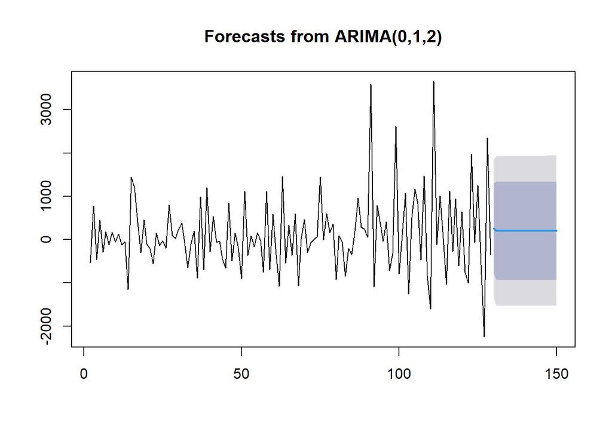

```r
data.ramalan.da <- ramalan.da$mean
plot(ramalan.da)
```

Berdasarkan hasil plot ramalan di atas, dapat dilihat bahwa ramalan ARIMA(0,1,2) cenderung stabil hingga akhir periode. Selanjutnya, dapat dicari nilai akurasi antara hasil ramalan dengan data uji sebagai berikut.

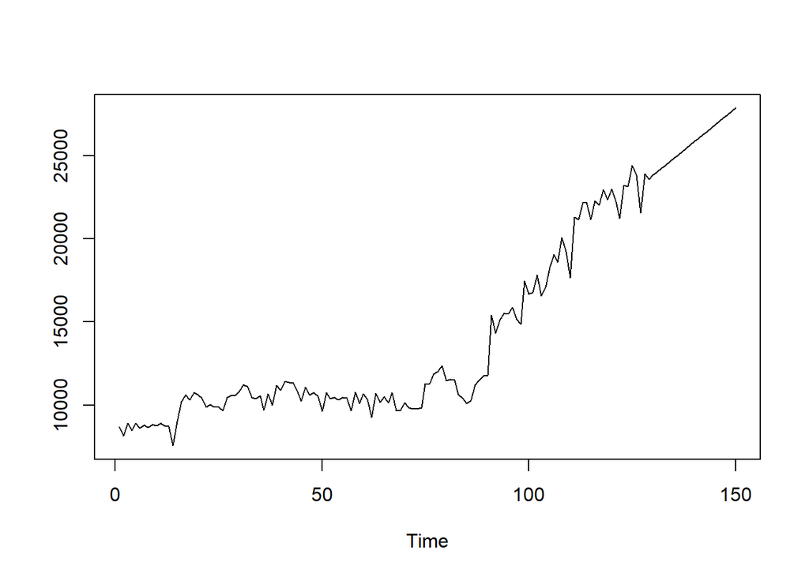

```r
pt_1 <- train.ts[0.86*n] #nilai akhir data latih
hasil.forc.Diff <- data.ramalan.da
hasil <- diffinv(hasil.forc.Diff, differences = 1) + pt_1
#has.1 sama hasilnta dengan: cumsum(c(pt_1,hasil.forc.Diff))
ts.plot(train.ts,hasil)
```

```r
perbandingan.da<-matrix(data=c(head(test.ts, n = 0.14*n), hasil[-1]),
                     nrow = 0.14*n, ncol = 2)
colnames(perbandingan.da)<-c("Aktual","Hasil Forecast")
perbandingan.da
```

```
##       Aktual Hasil Forecast
##  [1,]  24533       23821.25
##  [2,]  24104       24023.65
##  [3,]  24841       24226.06
##  [4,]  24185       24428.46
##  [5,]  21743       24630.86
##  [6,]  25775       24833.27
##  [7,]  25411       25035.67
##  [8,]  27385       25238.08
##  [9,]  24432       25440.48
## [10,]  27016       25642.88
## [11,]  27679       25845.29
## [12,]  26158       26047.69
## [13,]  28765       26250.10
## [14,]  28246       26452.50
## [15,]  29059       26654.90
## [16,]  28075       26857.31
## [17,]  25362       27059.71
## [18,]  29223       27262.11
## [19,]  28942       27464.52
## [20,]  28995       27666.92
## [21,]  24833       27869.33
```

```r
accuracy(ts(hasil[-1]), head(test.ts, n = 0.14*n))
```

```
##                ME     RMSE      MAE      MPE     MAPE        ACF1 Theil's U
## Test set 571.9506 1660.487 1417.078 1.789098 5.345009 -0.05484286  0.747295
```

# Kesimpulan

Model tentatif terbaik untuk memodelkan kasus jumlah penumpang KRL pada 150 periode awal yaitu ARIMA(0,1,2). Hal ini dikarenakan model tersebut memiliki nilai AIC terkecil di antara model lainnya dengan seluruh nilai parameternya signifikan. Nilai MAPE yang dihasilkan dari model ARIMA(0,1,2) sebesar 5.345009 kurang dari 10, artinya kemampuan model peramalan tergolong cukup baik.